# Risk Factor Analysis

## Outcome Variable

**Outcome Variable:** haz

## Predictor Variables

**Intervention Variable:** predexfd6

**Adjustment Set:**

- arm
- sex
- brthmon
- W_mage
- meducyrs
- feducyrs
- hhwealth_quart
- hfoodsec
- W_mhtcm
- W_mwtkg
- W_mbmi
- vagbrth
- W_gagebrth
- W_birthwt
- W_birthlen
- W_nrooms
- W_nchldlt5
- month
- W_parity
- impfloor
- impsan
- safeh20
- delta_W_mage
- delta_meducyrs
- delta_feducyrs
- delta_hhwealth_quart
- delta_hfoodsec
- delta_W_mhtcm
- delta_W_mwtkg
- delta_W_mbmi
- delta_vagbrth
- delta_W_gagebrth
- delta_W_birthwt
- delta_W_birthlen
- delta_W_nrooms
- delta_W_nchldlt5
- delta_month
- delta_W_parity
- delta_impfloor
- delta_impsan
- delta_safeh20

## Stratifying Variables

The analysis was stratified on these variable(s):

- agecat
- studyid
- country

## Data Summary

| agecat | studyid | country | predexfd6 | n_cell | n | outcome_variable |
| --- | --- | --- | --- | --- | --- | --- |
| Birth | CMC-V-BCS-2002 | INDIA | 1 | 7 | 7 | haz |
| Birth | CMC-V-BCS-2002 | INDIA | 0 | 0 | 7 | haz |
| Birth | EE | PAKISTAN | 1 | 38 | 42 | haz |
| Birth | EE | PAKISTAN | 0 | 4 | 42 | haz |
| Birth | GMS-Nepal | NEPAL | 1 | 419 | 563 | haz |
| Birth | GMS-Nepal | NEPAL | 0 | 144 | 563 | haz |
| Birth | IRC | INDIA | 1 | 0 | 14 | haz |
| Birth | IRC | INDIA | 0 | 14 | 14 | haz |
| Birth | JiVitA-3 | BANGLADESH | 1 | 10466 | 13423 | haz |
| Birth | JiVitA-3 | BANGLADESH | 0 | 2957 | 13423 | haz |
| Birth | JiVitA-4 | BANGLADESH | 1 | 2103 | 2632 | haz |
| Birth | JiVitA-4 | BANGLADESH | 0 | 529 | 2632 | haz |
| Birth | Keneba | GAMBIA | 1 | 485 | 1403 | haz |
| Birth | Keneba | GAMBIA | 0 | 918 | 1403 | haz |
| Birth | MAL-ED | BANGLADESH | 1 | 72 | 205 | haz |
| Birth | MAL-ED | BANGLADESH | 0 | 133 | 205 | haz |
| Birth | MAL-ED | BRAZIL | 1 | 6 | 60 | haz |
| Birth | MAL-ED | BRAZIL | 0 | 54 | 60 | haz |
| Birth | MAL-ED | INDIA | 1 | 4 | 39 | haz |
| Birth | MAL-ED | INDIA | 0 | 35 | 39 | haz |
| Birth | MAL-ED | NEPAL | 1 | 3 | 24 | haz |
| Birth | MAL-ED | NEPAL | 0 | 21 | 24 | haz |
| Birth | MAL-ED | PERU | 1 | 73 | 213 | haz |
| Birth | MAL-ED | PERU | 0 | 140 | 213 | haz |
| Birth | MAL-ED | SOUTH AFRICA | 1 | 1 | 91 | haz |
| Birth | MAL-ED | SOUTH AFRICA | 0 | 90 | 91 | haz |
| Birth | MAL-ED | TANZANIA, UNITED REPUBLIC OF | 1 | 0 | 113 | haz |
| Birth | MAL-ED | TANZANIA, UNITED REPUBLIC OF | 0 | 113 | 113 | haz |
| Birth | PROVIDE | BANGLADESH | 1 | 159 | 539 | haz |
| Birth | PROVIDE | BANGLADESH | 0 | 380 | 539 | haz |

[output cut: 70 more lines]

The following strata were considered:

- agecat: 24 months, studyid: CMC-V-BCS-2002, country: INDIA
- agecat: 24 months, studyid: EE, country: PAKISTAN
- agecat: 24 months, studyid: GMS-Nepal, country: NEPAL
- agecat: 24 months, studyid: IRC, country: INDIA
- agecat: 24 months, studyid: JiVitA-3, country: BANGLADESH
- agecat: 24 months, studyid: JiVitA-4, country: BANGLADESH
- agecat: 24 months, studyid: Keneba, country: GAMBIA
- agecat: 24 months, studyid: LCNI-5, country: MALAWI
- agecat: 24 months, studyid: MAL-ED, country: BANGLADESH
- agecat: 24 months, studyid: MAL-ED, country: BRAZIL
- agecat: 24 months, studyid: MAL-ED, country: INDIA
- agecat: 24 months, studyid: MAL-ED, country: NEPAL
- agecat: 24 months, studyid: MAL-ED, country: PERU
- agecat: 24 months, studyid: MAL-ED, country: SOUTH AFRICA
- agecat: 24 months, studyid: MAL-ED, country: TANZANIA, UNITED REPUBLIC OF
- agecat: 24 months, studyid: PROVIDE, country: BANGLADESH
- agecat: 6 months, studyid: CMC-V-BCS-2002, country: INDIA
- agecat: 6 months, studyid: EE, country: PAKISTAN
- agecat: 6 months, studyid: GMS-Nepal, country: NEPAL
- agecat: 6 months, studyid: IRC, country: INDIA
- agecat: 6 months, studyid: JiVitA-3, country: BANGLADESH
- agecat: 6 months, studyid: JiVitA-4, country: BANGLADESH
- agecat: 6 months, studyid: Keneba, country: GAMBIA
- agecat: 6 months, studyid: LCNI-5, country: MALAWI
- agecat: 6 months, studyid: MAL-ED, country: BANGLADESH
- agecat: 6 months, studyid: MAL-ED, country: BRAZIL
- agecat: 6 months, studyid: MAL-ED, country: INDIA
- agecat: 6 months, studyid: MAL-ED, country: NEPAL
- agecat: 6 months, studyid: MAL-ED, country: PERU
- agecat: 6 months, studyid: MAL-ED, country: SOUTH AFRICA
- agecat: 6 months, studyid: MAL-ED, country: TANZANIA, UNITED REPUBLIC OF
- agecat: 6 months, studyid: PROVIDE, country: BANGLADESH
- agecat: 6 months, studyid: SAS-CompFeed, country: INDIA
- agecat: 6 months, studyid: SAS-FoodSuppl, country: INDIA
- agecat: Birth, studyid: CMC-V-BCS-2002, country: INDIA
- agecat: Birth, studyid: EE, country: PAKISTAN
- agecat: Birth, studyid: GMS-Nepal, country: NEPAL
- agecat: Birth, studyid: IRC, country: INDIA
- agecat: Birth, studyid: JiVitA-3, country: BANGLADESH
- agecat: Birth, studyid: JiVitA-4, country: BANGLADESH
- agecat: Birth, studyid: Keneba, country: GAMBIA
- agecat: Birth, studyid: MAL-ED, country: BANGLADESH
- agecat: Birth, studyid: MAL-ED, country: BRAZIL
- agecat: Birth, studyid: MAL-ED, country: INDIA
- agecat: Birth, studyid: MAL-ED, country: NEPAL
- agecat: Birth, studyid: MAL-ED, country: PERU
- agecat: Birth, studyid: MAL-ED, country: SOUTH AFRICA
- agecat: Birth, studyid: MAL-ED, country: TANZANIA, UNITED REPUBLIC OF
- agecat: Birth, studyid: PROVIDE, country: BANGLADESH
- agecat: Birth, studyid: SAS-CompFeed, country: INDIA

### Dropped Strata

Some strata were dropped due to rare outcomes:

- agecat: Birth, studyid: CMC-V-BCS-2002, country: INDIA
- agecat: Birth, studyid: EE, country: PAKISTAN
- agecat: Birth, studyid: IRC, country: INDIA
- agecat: Birth, studyid: MAL-ED, country: INDIA
- agecat: Birth, studyid: MAL-ED, country: NEPAL
- agecat: Birth, studyid: MAL-ED, country: SOUTH AFRICA
- agecat: Birth, studyid: MAL-ED, country: TANZANIA, UNITED REPUBLIC OF
- agecat: 6 months, studyid: CMC-V-BCS-2002, country: INDIA
- agecat: 6 months, studyid: IRC, country: INDIA
- agecat: 6 months, studyid: MAL-ED, country: SOUTH AFRICA
- agecat: 6 months, studyid: MAL-ED, country: TANZANIA, UNITED REPUBLIC OF
- agecat: 6 months, studyid: SAS-FoodSuppl, country: INDIA
- agecat: 24 months, studyid: CMC-V-BCS-2002, country: INDIA
- agecat: 24 months, studyid: EE, country: PAKISTAN
- agecat: 24 months, studyid: IRC, country: INDIA
- agecat: 24 months, studyid: MAL-ED, country: SOUTH AFRICA
- agecat: 24 months, studyid: MAL-ED, country: TANZANIA, UNITED REPUBLIC OF

## Methods Detail

We’re interested in the causal parameters $E[Y_a]$ for all values of $a \in \mathcal{A}$. These parameters represent the mean outcome if, possibly contrary to fact, we intervened to set all units to have $A=a$. Under the randomization and positivity assumptions, these are identified by the statistical parameters $\psi_a=E_W[E_{Y|A,W}(Y|A=a,W)]$. In addition, we’re interested in the mean of $Y$, $E[Y]$ under no intervention (the observed mean). We will estimate these parameters by using SuperLearner to fit the relevant likelihood factors – $E_{Y|A,W}(Y|A=a,W)$ and $p(A=a|W)$, and then updating our likelihood fit using a joint TMLE.

For unadjusted analyses ($W=\{\}$), initial likelihoods were estimated using Lrnr_glm to estimate the simple $E(Y|A)$ and Lrnr_mean to estimate $p(A)$. For adjusted analyses, a small library containing Lrnr_glmnet, Lrnr_xgboost, and Lrnr_mean was used.

Having estimated these parameters, we will then use the delta method to estimate relative risks and attributable risks relative to a prespecified baseline level of $A$.

# Results Detail

## Results Plots

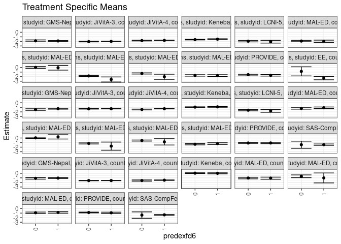

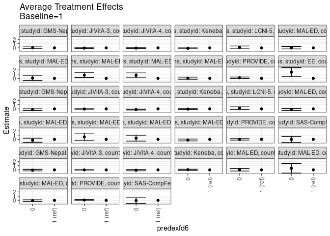

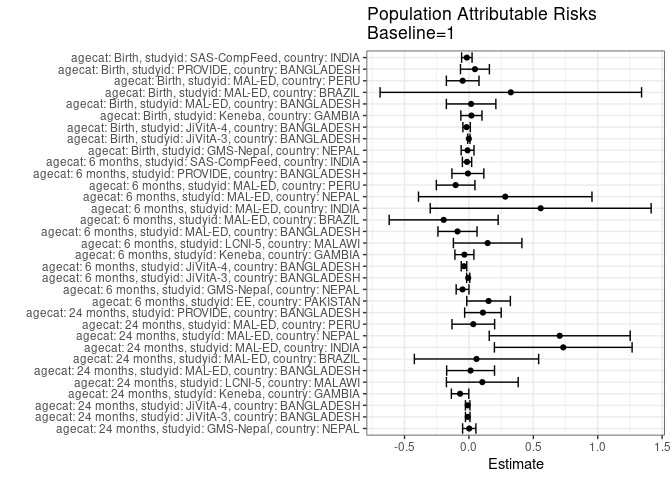

## Results Table

### Parameter: TSM

| agecat | studyid | country | intervention_level | baseline_level | estimate | ci_lower | ci_upper |
| --- | --- | --- | --- | --- | --- | --- | --- |
| Birth | GMS-Nepal | NEPAL | 1 | NA | -1.0536093 | -1.1509571 | -0.9562614 |
| Birth | GMS-Nepal | NEPAL | 0 | NA | -1.1059786 | -1.2822592 | -0.9296980 |
| Birth | JiVitA-3 | BANGLADESH | 1 | NA | -1.5948367 | -1.6196242 | -1.5700492 |
| Birth | JiVitA-3 | BANGLADESH | 0 | NA | -1.5979514 | -1.6372481 | -1.5586548 |
| Birth | JiVitA-4 | BANGLADESH | 1 | NA | -1.5090848 | -1.5617073 | -1.4564623 |
| Birth | JiVitA-4 | BANGLADESH | 0 | NA | -1.5920187 | -1.7239373 | -1.4601001 |
| Birth | Keneba | GAMBIA | 1 | NA | -0.0067106 | -0.1154636 | 0.1020424 |
| Birth | Keneba | GAMBIA | 0 | NA | 0.0275556 | -0.0511717 | 0.1062829 |
| Birth | MAL-ED | BANGLADESH | 1 | NA | -1.0700153 | -1.2993543 | -0.8406763 |
| Birth | MAL-ED | BANGLADESH | 0 | NA | -1.0435144 | -1.2203858 | -0.8666430 |
| Birth | MAL-ED | BRAZIL | 1 | NA | -1.0216667 | -2.1085384 | 0.0652051 |
| Birth | MAL-ED | BRAZIL | 0 | NA | -0.6601852 | -0.9595686 | -0.3608018 |
| Birth | MAL-ED | PERU | 1 | NA | -0.8582004 | -1.0209912 | -0.6954097 |
| Birth | MAL-ED | PERU | 0 | NA | -0.9188891 | -1.0665753 | -0.7712029 |
| Birth | PROVIDE | BANGLADESH | 1 | NA | -0.9319037 | -1.0667460 | -0.7970614 |
| Birth | PROVIDE | BANGLADESH | 0 | NA | -0.8700560 | -0.9567613 | -0.7833506 |
| Birth | SAS-CompFeed | INDIA | 1 | NA | -1.3776197 | -1.4631704 | -1.2920690 |
| Birth | SAS-CompFeed | INDIA | 0 | NA | -1.4364436 | -2.1366347 | -0.7362525 |
| 6 months | EE | PAKISTAN | 1 | NA | -2.3121318 | -2.6865239 | -1.9377397 |
| 6 months | EE | PAKISTAN | 0 | NA | -0.8473333 | -1.8424880 | 0.1478213 |
| 6 months | GMS-Nepal | NEPAL | 1 | NA | -1.3046923 | -1.3937744 | -1.2156102 |
| 6 months | GMS-Nepal | NEPAL | 0 | NA | -1.4851148 | -1.6545100 | -1.3157196 |
| 6 months | JiVitA-3 | BANGLADESH | 1 | NA | -1.3082269 | -1.3386850 | -1.2777689 |
| 6 months | JiVitA-3 | BANGLADESH | 0 | NA | -1.3299003 | -1.3792691 | -1.2805315 |
| 6 months | JiVitA-4 | BANGLADESH | 1 | NA | -1.3100276 | -1.3508087 | -1.2692464 |
| 6 months | JiVitA-4 | BANGLADESH | 0 | NA | -1.4775999 | -1.5693332 | -1.3858666 |
| 6 months | Keneba | GAMBIA | 1 | NA | -0.8980459 | -0.9868270 | -0.8092648 |
| 6 months | Keneba | GAMBIA | 0 | NA | -0.9482197 | -1.0070780 | -0.8893615 |
| 6 months | LCNI-5 | MALAWI | 1 | NA | -1.7849899 | -2.0750625 | -1.4949173 |
| 6 months | LCNI-5 | MALAWI | 0 | NA | -1.6285187 | -1.7597409 | -1.4972965 |
| 6 months | MAL-ED | BANGLADESH | 1 | NA | -1.1013574 | -1.2825090 | -0.9202059 |
| 6 months | MAL-ED | BANGLADESH | 0 | NA | -1.2404813 | -1.3969101 | -1.0840524 |
| 6 months | MAL-ED | BRAZIL | 1 | NA | 0.2435117 | -0.2220606 | 0.7090839 |
| 6 months | MAL-ED | BRAZIL | 0 | NA | 0.0326026 | -0.1181399 | 0.1833451 |
| 6 months | MAL-ED | INDIA | 1 | NA | -1.7758964 | -2.6661959 | -0.8855968 |
| 6 months | MAL-ED | INDIA | 0 | NA | -1.1918986 | -1.3128975 | -1.0708997 |
| 6 months | MAL-ED | NEPAL | 1 | NA | -0.8442294 | -1.5346670 | -0.1537919 |
| 6 months | MAL-ED | NEPAL | 0 | NA | -0.5553281 | -0.6737990 | -0.4368573 |
| 6 months | MAL-ED | PERU | 1 | NA | -1.2189739 | -1.3970067 | -1.0409411 |
| 6 months | MAL-ED | PERU | 0 | NA | -1.3596737 | -1.4964663 | -1.2228811 |
| 6 months | PROVIDE | BANGLADESH | 1 | NA | -1.0837114 | -1.2191339 | -0.9482889 |
| 6 months | PROVIDE | BANGLADESH | 0 | NA | -1.0913387 | -1.1793430 | -1.0033345 |
| 6 months | SAS-CompFeed | INDIA | 1 | NA | -1.4549959 | -1.6008850 | -1.3091069 |
| 6 months | SAS-CompFeed | INDIA | 0 | NA | -1.4654856 | -2.2428805 | -0.6880907 |
| 24 months | GMS-Nepal | NEPAL | 1 | NA | -1.9026614 | -1.9979099 | -1.8074128 |
| 24 months | GMS-Nepal | NEPAL | 0 | NA | -1.8766653 | -2.0740192 | -1.6793114 |
| 24 months | JiVitA-3 | BANGLADESH | 1 | NA | -2.0025043 | -2.0423720 | -1.9626366 |
| 24 months | JiVitA-3 | BANGLADESH | 0 | NA | -2.0450039 | -2.1146098 | -1.9753980 |
| 24 months | JiVitA-4 | BANGLADESH | 1 | NA | -1.7818219 | -1.8237312 | -1.7399126 |
| 24 months | JiVitA-4 | BANGLADESH | 0 | NA | -1.8282119 | -1.9050473 | -1.7513764 |
| 24 months | Keneba | GAMBIA | 1 | NA | -1.5191442 | -1.6021949 | -1.4360935 |
| 24 months | Keneba | GAMBIA | 0 | NA | -1.6175248 | -1.6825454 | -1.5525042 |
| 24 months | LCNI-5 | MALAWI | 1 | NA | -2.0690908 | -2.3663713 | -1.7718102 |
| 24 months | LCNI-5 | MALAWI | 0 | NA | -1.9534768 | -2.1123713 | -1.7945824 |
| 24 months | MAL-ED | BANGLADESH | 1 | NA | -1.9705382 | -2.2162726 | -1.7248038 |
| 24 months | MAL-ED | BANGLADESH | 0 | NA | -1.9247498 | -2.0695676 | -1.7799320 |
| 24 months | MAL-ED | BRAZIL | 1 | NA | -0.0527266 | -0.5710389 | 0.4655858 |
| 24 months | MAL-ED | BRAZIL | 0 | NA | 0.0136341 | -0.1717520 | 0.1990201 |
| 24 months | MAL-ED | INDIA | 1 | NA | -2.6187386 | -3.1683903 | -2.0690869 |
| 24 months | MAL-ED | INDIA | 0 | NA | -1.8477329 | -1.9793388 | -1.7161270 |
| 24 months | MAL-ED | NEPAL | 1 | NA | -2.0237111 | -2.5803876 | -1.4670346 |
| 24 months | MAL-ED | NEPAL | 0 | NA | -1.3054223 | -1.4309583 | -1.1798864 |
| 24 months | MAL-ED | PERU | 1 | NA | -1.7864976 | -1.9886046 | -1.5843907 |
| 24 months | MAL-ED | PERU | 0 | NA | -1.7346130 | -1.8833823 | -1.5858438 |
| 24 months | PROVIDE | BANGLADESH | 1 | NA | -1.7110789 | -1.8717765 | -1.5503813 |
| 24 months | PROVIDE | BANGLADESH | 0 | NA | -1.5701732 | -1.6661947 | -1.4741517 |

### Parameter: E(Y)

| agecat | studyid | country | intervention_level | baseline_level | estimate | ci_lower | ci_upper |
| --- | --- | --- | --- | --- | --- | --- | --- |
| Birth | GMS-Nepal | NEPAL | NA | NA | -1.0641208 | -1.1525364 | -0.9757052 |
| Birth | JiVitA-3 | BANGLADESH | NA | NA | -1.5955338 | -1.6186322 | -1.5724354 |
| Birth | JiVitA-4 | BANGLADESH | NA | NA | -1.5273138 | -1.5765339 | -1.4780937 |
| Birth | Keneba | GAMBIA | NA | NA | 0.0126443 | -0.0554367 | 0.0807254 |
| Birth | MAL-ED | BANGLADESH | NA | NA | -1.0530244 | -1.1913751 | -0.9146736 |
| Birth | MAL-ED | BRAZIL | NA | NA | -0.6963333 | -0.9881882 | -0.4044785 |
| Birth | MAL-ED | PERU | NA | NA | -0.9065728 | -1.0297267 | -0.7834188 |
| Birth | PROVIDE | BANGLADESH | NA | NA | -0.8851020 | -0.9601332 | -0.8100709 |
| Birth | SAS-CompFeed | INDIA | NA | NA | -1.3937088 | -1.5095039 | -1.2779137 |
| 6 months | EE | PAKISTAN | NA | NA | -2.1595486 | -2.5331781 | -1.7859192 |
| 6 months | GMS-Nepal | NEPAL | NA | NA | -1.3540280 | -1.4334801 | -1.2745760 |
| 6 months | JiVitA-3 | BANGLADESH | NA | NA | -1.3138259 | -1.3418712 | -1.2857806 |
| 6 months | JiVitA-4 | BANGLADESH | NA | NA | -1.3482303 | -1.3866421 | -1.3098185 |
| 6 months | Keneba | GAMBIA | NA | NA | -0.9331108 | -0.9823173 | -0.8839043 |
| 6 months | LCNI-5 | MALAWI | NA | NA | -1.6395956 | -1.7592633 | -1.5199278 |
| 6 months | MAL-ED | BANGLADESH | NA | NA | -1.1900794 | -1.3096296 | -1.0705291 |
| 6 months | MAL-ED | BRAZIL | NA | NA | 0.0475758 | -0.0963508 | 0.1915023 |
| 6 months | MAL-ED | INDIA | NA | NA | -1.2188303 | -1.3423090 | -1.0953516 |
| 6 months | MAL-ED | NEPAL | NA | NA | -0.5622370 | -0.6774081 | -0.4470660 |
| 6 months | MAL-ED | PERU | NA | NA | -1.3220326 | -1.4308168 | -1.2132484 |
| 6 months | PROVIDE | BANGLADESH | NA | NA | -1.0916915 | -1.1661176 | -1.0172654 |
| 6 months | SAS-CompFeed | INDIA | NA | NA | -1.4697236 | -1.6333919 | -1.3060553 |
| 24 months | GMS-Nepal | NEPAL | NA | NA | -1.9002128 | -1.9869255 | -1.8135001 |
| 24 months | JiVitA-3 | BANGLADESH | NA | NA | -2.0118003 | -2.0479952 | -1.9756055 |
| 24 months | JiVitA-4 | BANGLADESH | NA | NA | -1.7914765 | -1.8297816 | -1.7531715 |
| 24 months | Keneba | GAMBIA | NA | NA | -1.5876293 | -1.6406755 | -1.5345831 |
| 24 months | LCNI-5 | MALAWI | NA | NA | -1.9651323 | -2.1053230 | -1.8249415 |
| 24 months | MAL-ED | BANGLADESH | NA | NA | -1.9576341 | -2.0857597 | -1.8295086 |
| 24 months | MAL-ED | BRAZIL | NA | NA | 0.0061144 | -0.1625850 | 0.1748138 |
| 24 months | MAL-ED | INDIA | NA | NA | -1.8863397 | -2.0168508 | -1.7558287 |
| 24 months | MAL-ED | NEPAL | NA | NA | -1.3187671 | -1.4406685 | -1.1968657 |
| 24 months | MAL-ED | PERU | NA | NA | -1.7524710 | -1.8736426 | -1.6312994 |
| 24 months | PROVIDE | BANGLADESH | NA | NA | -1.6024221 | -1.6857420 | -1.5191023 |

### Parameter: ATE

| agecat | studyid | country | intervention_level | baseline_level | estimate | ci_lower | ci_upper |
| --- | --- | --- | --- | --- | --- | --- | --- |
| Birth | GMS-Nepal | NEPAL | 1 | 1 | 0.0000000 | 0.0000000 | 0.0000000 |
| Birth | GMS-Nepal | NEPAL | 0 | 1 | -0.0523693 | -0.2466389 | 0.1419003 |
| Birth | JiVitA-3 | BANGLADESH | 1 | 1 | 0.0000000 | 0.0000000 | 0.0000000 |
| Birth | JiVitA-3 | BANGLADESH | 0 | 1 | -0.0031147 | -0.0438864 | 0.0376570 |
| Birth | JiVitA-4 | BANGLADESH | 1 | 1 | 0.0000000 | 0.0000000 | 0.0000000 |
| Birth | JiVitA-4 | BANGLADESH | 0 | 1 | -0.0829339 | -0.2243612 | 0.0584934 |
| Birth | Keneba | GAMBIA | 1 | 1 | 0.0000000 | 0.0000000 | 0.0000000 |
| Birth | Keneba | GAMBIA | 0 | 1 | 0.0342662 | -0.0896145 | 0.1581470 |
| Birth | MAL-ED | BANGLADESH | 1 | 1 | 0.0000000 | 0.0000000 | 0.0000000 |
| Birth | MAL-ED | BANGLADESH | 0 | 1 | 0.0265009 | -0.2645819 | 0.3175837 |
| Birth | MAL-ED | BRAZIL | 1 | 1 | 0.0000000 | 0.0000000 | 0.0000000 |
| Birth | MAL-ED | BRAZIL | 0 | 1 | 0.3614815 | -0.7658697 | 1.4888326 |
| Birth | MAL-ED | PERU | 1 | 1 | 0.0000000 | 0.0000000 | 0.0000000 |
| Birth | MAL-ED | PERU | 0 | 1 | -0.0606887 | -0.2521723 | 0.1307949 |
| Birth | PROVIDE | BANGLADESH | 1 | 1 | 0.0000000 | 0.0000000 | 0.0000000 |
| Birth | PROVIDE | BANGLADESH | 0 | 1 | 0.0618477 | -0.0870803 | 0.2107757 |
| Birth | SAS-CompFeed | INDIA | 1 | 1 | 0.0000000 | 0.0000000 | 0.0000000 |
| Birth | SAS-CompFeed | INDIA | 0 | 1 | -0.0588239 | -0.7253365 | 0.6076887 |
| 6 months | EE | PAKISTAN | 1 | 1 | 0.0000000 | 0.0000000 | 0.0000000 |
| 6 months | EE | PAKISTAN | 0 | 1 | 1.4647984 | 0.4015477 | 2.5280492 |
| 6 months | GMS-Nepal | NEPAL | 1 | 1 | 0.0000000 | 0.0000000 | 0.0000000 |
| 6 months | GMS-Nepal | NEPAL | 0 | 1 | -0.1804225 | -0.3719103 | 0.0110654 |
| 6 months | JiVitA-3 | BANGLADESH | 1 | 1 | 0.0000000 | 0.0000000 | 0.0000000 |
| 6 months | JiVitA-3 | BANGLADESH | 0 | 1 | -0.0216734 | -0.0742043 | 0.0308576 |
| 6 months | JiVitA-4 | BANGLADESH | 1 | 1 | 0.0000000 | 0.0000000 | 0.0000000 |
| 6 months | JiVitA-4 | BANGLADESH | 0 | 1 | -0.1675723 | -0.2665738 | -0.0685708 |
| 6 months | Keneba | GAMBIA | 1 | 1 | 0.0000000 | 0.0000000 | 0.0000000 |
| 6 months | Keneba | GAMBIA | 0 | 1 | -0.0501738 | -0.1560479 | 0.0557003 |
| 6 months | LCNI-5 | MALAWI | 1 | 1 | 0.0000000 | 0.0000000 | 0.0000000 |
| 6 months | LCNI-5 | MALAWI | 0 | 1 | 0.1564712 | -0.1630250 | 0.4759674 |
| 6 months | MAL-ED | BANGLADESH | 1 | 1 | 0.0000000 | 0.0000000 | 0.0000000 |
| 6 months | MAL-ED | BANGLADESH | 0 | 1 | -0.1391238 | -0.3786446 | 0.1003969 |
| 6 months | MAL-ED | BRAZIL | 1 | 1 | 0.0000000 | 0.0000000 | 0.0000000 |
| 6 months | MAL-ED | BRAZIL | 0 | 1 | -0.2109091 | -0.7014554 | 0.2796373 |
| 6 months | MAL-ED | INDIA | 1 | 1 | 0.0000000 | 0.0000000 | 0.0000000 |
| 6 months | MAL-ED | INDIA | 0 | 1 | 0.5839978 | -0.3152765 | 1.4832720 |
| 6 months | MAL-ED | NEPAL | 1 | 1 | 0.0000000 | 0.0000000 | 0.0000000 |
| 6 months | MAL-ED | NEPAL | 0 | 1 | 0.2889013 | -0.4121848 | 0.9899874 |
| 6 months | MAL-ED | PERU | 1 | 1 | 0.0000000 | 0.0000000 | 0.0000000 |
| 6 months | MAL-ED | PERU | 0 | 1 | -0.1406998 | -0.3655726 | 0.0841730 |
| 6 months | PROVIDE | BANGLADESH | 1 | 1 | 0.0000000 | 0.0000000 | 0.0000000 |
| 6 months | PROVIDE | BANGLADESH | 0 | 1 | -0.0076273 | -0.1691797 | 0.1539250 |
| 6 months | SAS-CompFeed | INDIA | 1 | 1 | 0.0000000 | 0.0000000 | 0.0000000 |
| 6 months | SAS-CompFeed | INDIA | 0 | 1 | -0.0104897 | -0.7471588 | 0.7261794 |
| 24 months | GMS-Nepal | NEPAL | 1 | 1 | 0.0000000 | 0.0000000 | 0.0000000 |
| 24 months | GMS-Nepal | NEPAL | 0 | 1 | 0.0259961 | -0.1911209 | 0.2431131 |
| 24 months | JiVitA-3 | BANGLADESH | 1 | 1 | 0.0000000 | 0.0000000 | 0.0000000 |
| 24 months | JiVitA-3 | BANGLADESH | 0 | 1 | -0.0424996 | -0.1189898 | 0.0339905 |
| 24 months | JiVitA-4 | BANGLADESH | 1 | 1 | 0.0000000 | 0.0000000 | 0.0000000 |
| 24 months | JiVitA-4 | BANGLADESH | 0 | 1 | -0.0463900 | -0.1288993 | 0.0361193 |
| 24 months | Keneba | GAMBIA | 1 | 1 | 0.0000000 | 0.0000000 | 0.0000000 |
| 24 months | Keneba | GAMBIA | 0 | 1 | -0.0983806 | -0.2002972 | 0.0035360 |
| 24 months | LCNI-5 | MALAWI | 1 | 1 | 0.0000000 | 0.0000000 | 0.0000000 |
| 24 months | LCNI-5 | MALAWI | 0 | 1 | 0.1156139 | -0.2223172 | 0.4535451 |
| 24 months | MAL-ED | BANGLADESH | 1 | 1 | 0.0000000 | 0.0000000 | 0.0000000 |
| 24 months | MAL-ED | BANGLADESH | 0 | 1 | 0.0457885 | -0.2385355 | 0.3301124 |
| 24 months | MAL-ED | BRAZIL | 1 | 1 | 0.0000000 | 0.0000000 | 0.0000000 |
| 24 months | MAL-ED | BRAZIL | 0 | 1 | 0.0663606 | -0.4854803 | 0.6182016 |
| 24 months | MAL-ED | INDIA | 1 | 1 | 0.0000000 | 0.0000000 | 0.0000000 |
| 24 months | MAL-ED | INDIA | 0 | 1 | 0.7710057 | 0.2058612 | 1.3361503 |
| 24 months | MAL-ED | NEPAL | 1 | 1 | 0.0000000 | 0.0000000 | 0.0000000 |
| 24 months | MAL-ED | NEPAL | 0 | 1 | 0.7182888 | 0.1448739 | 1.2917036 |
| 24 months | MAL-ED | PERU | 1 | 1 | 0.0000000 | 0.0000000 | 0.0000000 |
| 24 months | MAL-ED | PERU | 0 | 1 | 0.0518846 | -0.1954141 | 0.2991833 |
| 24 months | PROVIDE | BANGLADESH | 1 | 1 | 0.0000000 | 0.0000000 | 0.0000000 |
| 24 months | PROVIDE | BANGLADESH | 0 | 1 | 0.1409056 | -0.0440929 | 0.3259042 |

### Parameter: PAR

| agecat | studyid | country | intervention_level | baseline_level | estimate | ci_lower | ci_upper |
| --- | --- | --- | --- | --- | --- | --- | --- |
| Birth | GMS-Nepal | NEPAL | 1 | NA | -0.0105115 | -0.0603390 | 0.0393160 |
| Birth | JiVitA-3 | BANGLADESH | 1 | NA | -0.0006971 | -0.0096837 | 0.0082895 |
| Birth | JiVitA-4 | BANGLADESH | 1 | NA | -0.0182290 | -0.0469125 | 0.0104545 |
| Birth | Keneba | GAMBIA | 1 | NA | 0.0193549 | -0.0624889 | 0.1011988 |
| Birth | MAL-ED | BANGLADESH | 1 | NA | 0.0169909 | -0.1751495 | 0.2091312 |
| Birth | MAL-ED | BRAZIL | 1 | NA | 0.3253333 | -0.6896600 | 1.3403266 |
| Birth | MAL-ED | PERU | 1 | NA | -0.0483723 | -0.1751059 | 0.0783612 |
| Birth | PROVIDE | BANGLADESH | 1 | NA | 0.0468016 | -0.0654654 | 0.1590687 |
| Birth | SAS-CompFeed | INDIA | 1 | NA | -0.0160891 | -0.0566754 | 0.0244973 |
| 6 months | EE | PAKISTAN | 1 | NA | 0.1525832 | -0.0166253 | 0.3217917 |
| 6 months | GMS-Nepal | NEPAL | 1 | NA | -0.0493357 | -0.0990875 | 0.0004161 |
| 6 months | JiVitA-3 | BANGLADESH | 1 | NA | -0.0055989 | -0.0175801 | 0.0063823 |
| 6 months | JiVitA-4 | BANGLADESH | 1 | NA | -0.0382028 | -0.0596044 | -0.0168011 |
| 6 months | Keneba | GAMBIA | 1 | NA | -0.0350649 | -0.1087940 | 0.0386643 |
| 6 months | LCNI-5 | MALAWI | 1 | NA | 0.1453943 | -0.1205024 | 0.4112909 |
| 6 months | MAL-ED | BANGLADESH | 1 | NA | -0.0887219 | -0.2404078 | 0.0629640 |
| 6 months | MAL-ED | BRAZIL | 1 | NA | -0.1959359 | -0.6189153 | 0.2270435 |
| 6 months | MAL-ED | INDIA | 1 | NA | 0.5570661 | -0.3005405 | 1.4146726 |
| 6 months | MAL-ED | NEPAL | 1 | NA | 0.2819924 | -0.3914364 | 0.9554212 |
| 6 months | MAL-ED | PERU | 1 | NA | -0.1030587 | -0.2528230 | 0.0467057 |
| 6 months | PROVIDE | BANGLADESH | 1 | NA | -0.0079801 | -0.1318996 | 0.1159395 |
| 6 months | SAS-CompFeed | INDIA | 1 | NA | -0.0147277 | -0.0507565 | 0.0213012 |
| 24 months | GMS-Nepal | NEPAL | 1 | NA | 0.0024486 | -0.0490692 | 0.0539664 |
| 24 months | JiVitA-3 | BANGLADESH | 1 | NA | -0.0092960 | -0.0268446 | 0.0082526 |
| 24 months | JiVitA-4 | BANGLADESH | 1 | NA | -0.0096547 | -0.0271358 | 0.0078265 |
| 24 months | Keneba | GAMBIA | 1 | NA | -0.0684851 | -0.1362124 | -0.0007578 |
| 24 months | LCNI-5 | MALAWI | 1 | NA | 0.1039585 | -0.1746649 | 0.3825819 |
| 24 months | MAL-ED | BANGLADESH | 1 | NA | 0.0129041 | -0.1729196 | 0.1987278 |
| 24 months | MAL-ED | BRAZIL | 1 | NA | 0.0588410 | -0.4237037 | 0.5413857 |
| 24 months | MAL-ED | INDIA | 1 | NA | 0.7323989 | 0.1977988 | 1.2669990 |
| 24 months | MAL-ED | NEPAL | 1 | NA | 0.7049440 | 0.1576978 | 1.2521902 |
| 24 months | MAL-ED | PERU | 1 | NA | 0.0340267 | -0.1315763 | 0.1996296 |
| 24 months | PROVIDE | BANGLADESH | 1 | NA | 0.1086567 | -0.0332063 | 0.2505198 |